# Tugas Praktikum Pemodelan ARIMA

# Packages

```r
library(readxl)
library(ggplot2)
library(tsibble)
library(tseries)
library(MASS)
library(forecast)
library(TSA)
library(lmtest)
```

# Data

Data yang digunakan adalah **MLTempDataset**, yaitu data per jam dengan peubah `DAYTON_MW`. Data penuh berisi 6.676 amatan (4 Januari 2022 00:00 sampai 9 Oktober 2022 03:00). Di tugas ini digunakan **500 amatan pertama**.

```r
data <- read_excel("MLTempDataset.xlsx", .name_repair = "minimal")
str(data)
```

```
## tibble [6,676 × 4] (S3: tbl_df/tbl/data.frame)
##  $          : num [1:6676] 0 1 2 3 4 5 6 7 8 9 ...
##  $ Datetime1: num [1:6676] 0 1 2 3 4 5 6 7 8 9 ...
##  $ DAYTON_MW: num [1:6676] 20.9 21 20.9 20.6 20.4 ...
##  $ Datetime : chr [1:6676] "04/01/2022 00:00" "04/01/2022 01:00" "04/01/2022 02:00" "04/01/2022 03:00" ...
```

```r
data500 <- data[1:500, c("Datetime", "DAYTON_MW")]
head(data500)
```

```
## # A tibble: 6 × 2
##   Datetime         DAYTON_MW
##   <chr>                <dbl>
## 1 04/01/2022 00:00      20.9
## 2 04/01/2022 01:00      21
## 3 04/01/2022 02:00      20.9
## 4 04/01/2022 03:00      20.6
## 5 04/01/2022 04:00      20.4
## 6 04/01/2022 05:00      20.1
```

```r
tail(data500)
```

```
## # A tibble: 6 × 2
##   Datetime         DAYTON_MW
##   <chr>                <dbl>
## 1 24/01/2022 14:00      9.17
## 2 24/01/2022 15:00     12.1
## 3 24/01/2022 16:00      9.7
## 4 24/01/2022 17:00     16.3
## 5 24/01/2022 18:00     15.7
## 6 24/01/2022 19:00     17.9
```

```r
data.ts <- ts(data500$DAYTON_MW)
summary(data.ts)
```

```
##    Min. 1st Qu.  Median    Mean 3rd Qu.    Max.
##   7.067  14.250  20.800  18.862  23.008  26.767
```

## Plot data penuh (500 amatan)

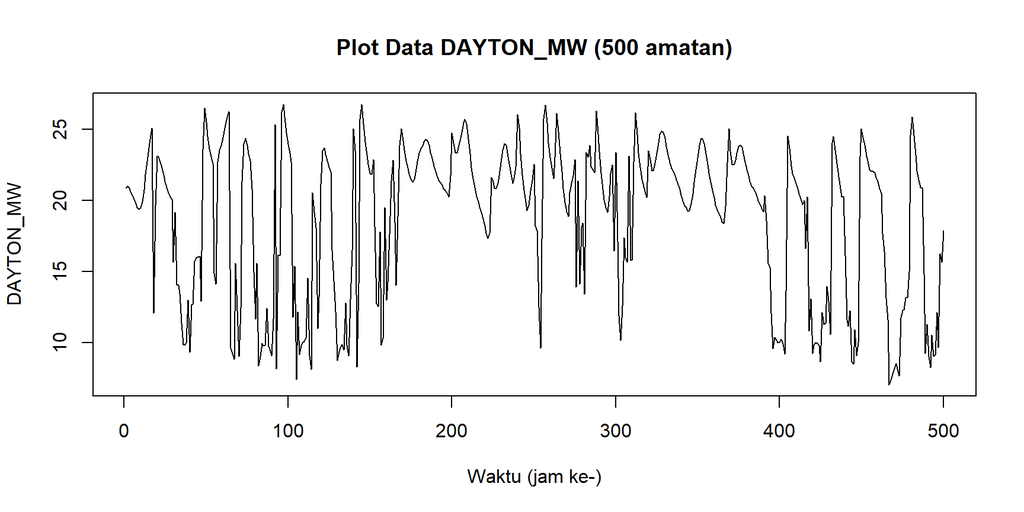

```r
plot.ts(data.ts,
        lty = 1,
        xlab = "Waktu (jam ke-)",
        ylab = "DAYTON_MW",
        main = "Plot Data DAYTON_MW (500 amatan)")
```

Plot memperlihatkan data berfluktuasi di sekitar nilai tengah tanpa tren naik atau turun yang jelas. Terdapat penurunan tajam berulang, sehingga sebaran data cenderung menjulur ke kiri. Terlihat juga pola naik-turun yang berulang.

# Tahap 1: Pembagian data latih dan data uji

Pembagian data dilakukan dengan proporsi **90% : 10%**, yaitu 450 amatan pertama sebagai data latih dan 50 amatan terakhir sebagai data uji. Proporsi data uji dibuat lebih kecil karena model ARIMA pada data per jam hanya informatif untuk horizon pendek.

```r
train <- data.ts[1:450]
test  <- data.ts[451:500]
train.ts <- ts(train)
test.ts  <- ts(test, start = 451)
```

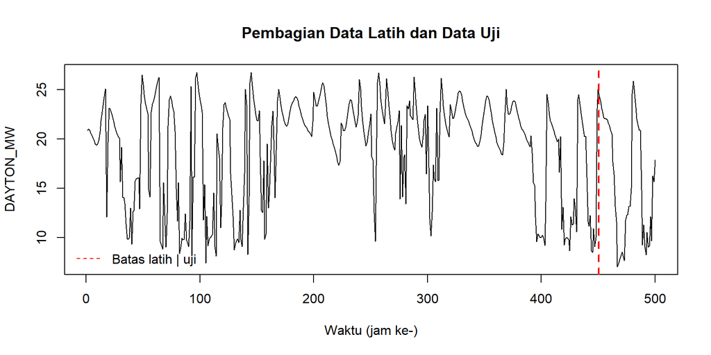

```r
plot.ts(data.ts, xlab = "Waktu (jam ke-)", ylab = "DAYTON_MW",
        main = "Pembagian Data Latih dan Data Uji")
abline(v = 450.5, col = "red", lty = 2, lwd = 2)
legend("bottomleft", legend = c("Batas latih | uji"), col = "red", lty = 2, bty = "n")
```

## Plot data latih

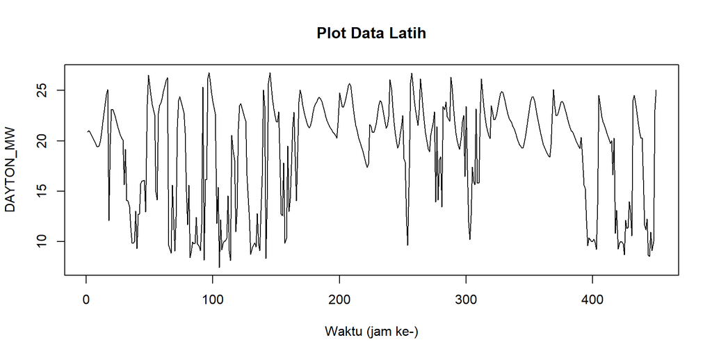

```r
plot.ts(train.ts, lty = 1, xlab = "Waktu (jam ke-)", ylab = "DAYTON_MW",
        main = "Plot Data Latih")
```

## Plot data uji

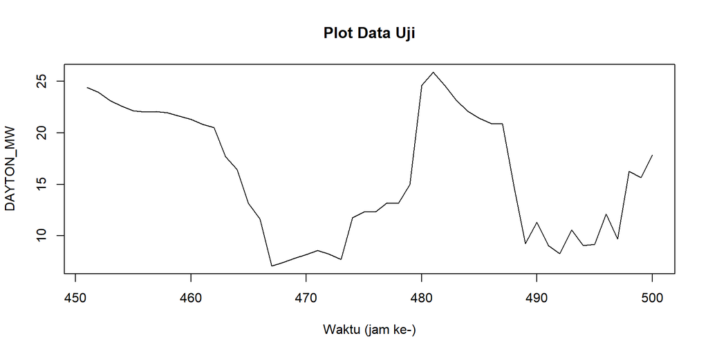

```r
plot.ts(test.ts, lty = 1, xlab = "Waktu (jam ke-)", ylab = "DAYTON_MW",
        main = "Plot Data Uji")
```

# Tahap 2: Uji stasioneritas data latih

## Stasioneritas dalam rataan

### Plot ACF

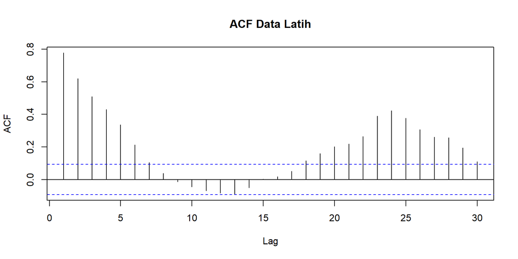

```r
acf(train.ts, lag.max = 30, main = "ACF Data Latih")
```

Plot ACF menunjukkan autokorelasi yang menurun cukup cepat dan masuk batas signifikansi sekitar lag ke-8, sehingga data latih dapat dianggap stasioner dalam rataan. Kenaikan ACF kembali pada lag 22–26 mengindikasikan adanya pola harian (24 jam).

### Uji ADF

```r
adf.train <- tseries::adf.test(train.ts)
adf.train
```

```
##
##  Augmented Dickey-Fuller Test
##
## data:  train.ts
## Dickey-Fuller = -6.4034, Lag order = 7, p-value = 0.01
## alternative hypothesis: stationary
```

$H_0$ : Data tidak stasioner dalam rataan

$H_1$ : Data stasioner dalam rataan

Berdasarkan uji ADF, didapat *p-value* sebesar 0.01 kurang dari taraf nyata 5% sehingga **tolak $H_0$**. Artinya, data latih **stasioner dalam rataan**, hasil ini sesuai dengan plot deret waktu dan plot ACF, sehingga **tidak perlu dilakukan *differencing***.

## Stasioneritas dalam ragam

### Plot Box-Cox

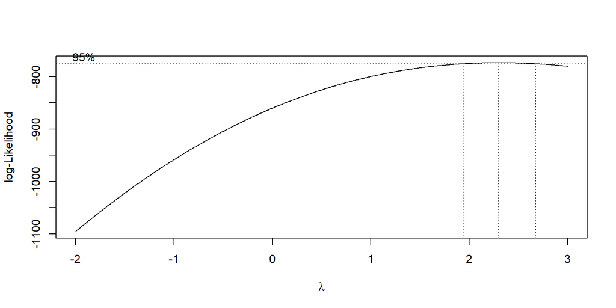

```r
index <- seq(1:450)

bc <- boxcox(train.ts ~ index, lambda = seq(-2, 3, by = 0.01))
```

```r
# Nilai lambda optimum
lambda <- bc$x[which.max(bc$y)]
lambda
```

```
## [1] 2.3
```

```r
# Selang kepercayaan 95% untuk lambda
ci_lambda <- bc$x[bc$y > max(bc$y) - 0.5 * qchisq(0.95, 1)]

ci_lower <- min(ci_lambda)
ci_upper <- max(ci_lambda)

c(Batas_Bawah = ci_lower, Batas_Atas = ci_upper)
```

```
## Batas_Bawah  Batas_Atas
##        1.95        2.67
```

Nilai $\lambda$ optimum sebesar 2.3 dengan selang kepercayaan 95% (1.95; 2.67). Selang tersebut **tidak memuat nilai 1**, sehingga data latih **tidak stasioner dalam ragam** dan perlu ditransformasi.

# Tahap 3: Penanganan ketidakstasioneran

## Transformasi Box-Cox

Karena selang kepercayaan $\lambda$ memuat nilai 2, digunakan $\lambda$ yang dibulatkan, yaitu $\lambda = 2$. Transformasi yang dilakukan adalah transformasi kuadrat:

$$Z_t = Y_t^{2}$$

Seluruh data bernilai positif (minimum 7.45), sehingga tidak perlu penambahan konstanta.

```r
lambda.bulat <- 2
train.bc <- train.ts^lambda.bulat
```

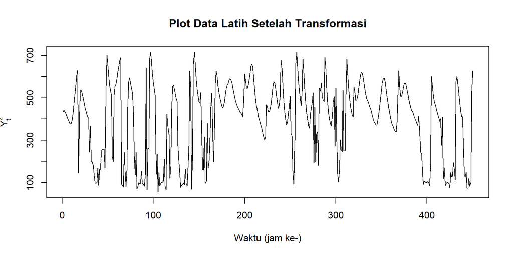

```r
plot.ts(train.bc, lty = 1, xlab = "Waktu (jam ke-)", ylab = expression(Y[t]^2),
        main = "Plot Data Latih Setelah Transformasi")
```

## Pengecekan ulang stasioneritas dalam ragam

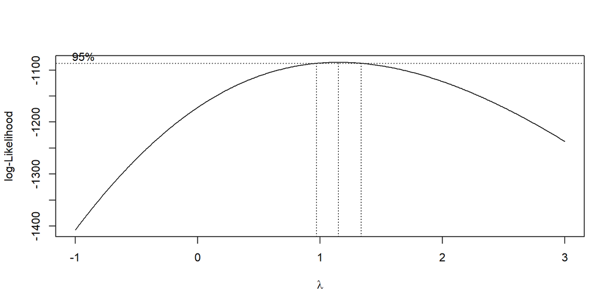

```r
bc2 <- boxcox(train.bc ~ index, lambda = seq(-1, 3, by = 0.01))
```

```r
lambda2 <- bc2$x[which.max(bc2$y)]
lambda2
```

```
## [1] 1.15
```

```r
ci_lambda2 <- bc2$x[bc2$y > max(bc2$y) - 0.5 * qchisq(0.95, 1)]
c(Batas_Bawah = min(ci_lambda2), Batas_Atas = max(ci_lambda2))
```

```
## Batas_Bawah  Batas_Atas
##        0.98        1.33
```

Setelah transformasi, nilai $\lambda$ optimum sebesar 1.15 dengan selang kepercayaan 95% (0.98; 1.33). Selang tersebut **memuat nilai 1**, sehingga data hasil transformasi sudah **stasioner dalam ragam**.

## Pengecekan ulang stasioneritas dalam rataan

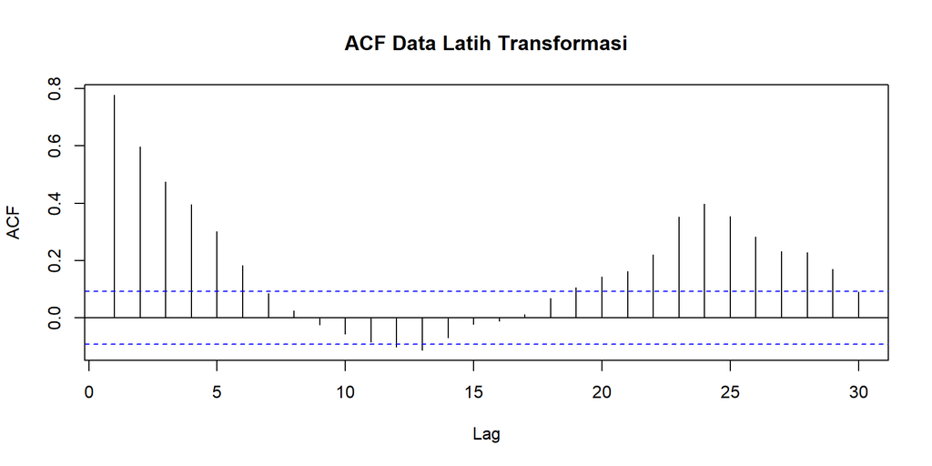

```r
acf(train.bc, lag.max = 30, main = "ACF Data Latih Transformasi")
```

```r
adf.bc <- tseries::adf.test(train.bc)
adf.bc
```

```
##
##  Augmented Dickey-Fuller Test
##
## data:  train.bc
## Dickey-Fuller = -6.2899, Lag order = 7, p-value = 0.01
## alternative hypothesis: stationary
```

$H_0$ : Data tidak stasioner dalam rataan

$H_1$ : Data stasioner dalam rataan

Uji ADF pada data transformasi menghasilkan *p-value* 0.01 < 5%, sehingga tolak $H_0$. Data transformasi tetap **stasioner dalam rataan**, sehingga pemodelan dilakukan tanpa *differencing* ($d = 0$).

# Tahap 4: Identifikasi model

## Plot ACF

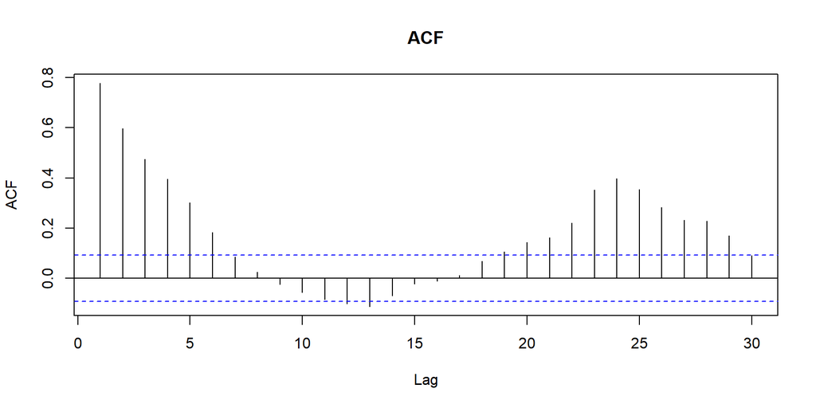

```r
acf(train.bc, lag.max = 30, main = "ACF")
```

Plot ACF cenderung *tails off* secara eksponensial. Jika ACF dianggap *cuts off* pada lag ke-6 (lag terakhir yang signifikan sebelum masuk batas), modelnya adalah **ARIMA(0,0,6)**.

## Plot PACF

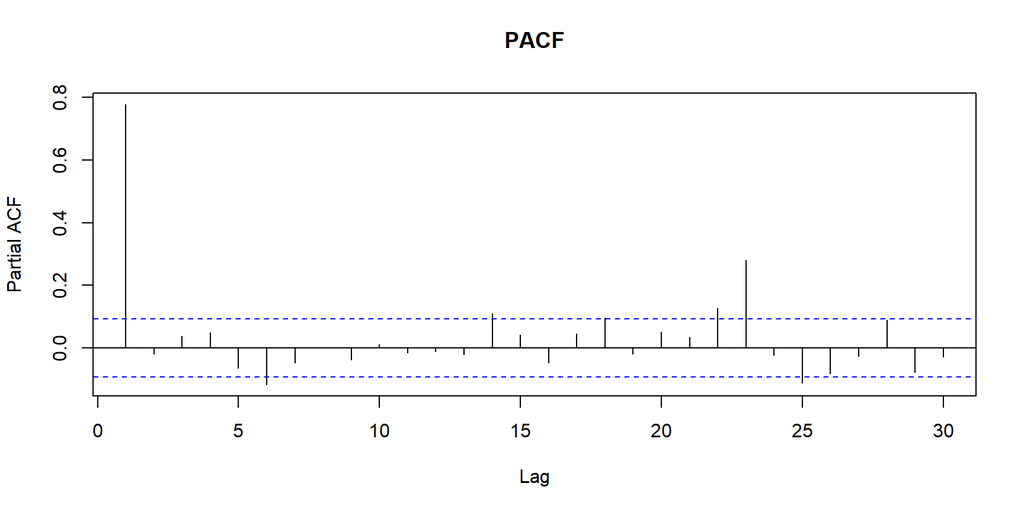

```r
pacf(train.bc, lag.max = 30, main = "PACF")
```

Plot PACF *cuts off* pada lag pertama, sedangkan ACF *tails off*, sehingga model tentatifnya adalah **ARIMA(1,0,0)**. Jika ACF dan PACF sama-sama dianggap *tails off*, model tentatifnya adalah **ARIMA(1,0,1)**.

## Plot EACF

```r
eacf(train.bc)
```

```
## AR/MA
##   0 1 2 3 4 5 6 7 8 9 10 11 12 13
## 0 x x x x x x o o o o o  x  x  o
## 1 o o o o x x o o o o o  o  x  o
## 2 x o o o x o o o o o o  o  x  o
## 3 x x o o o o x o o o o  o  o  o
## 4 x x o o o o x o o o o  o  o  o
## 5 x x x o o o o o o o o  o  o  o
## 6 x x x o o x o o o o o  o  o  o
## 7 o x x o o x o o o o o  o  o  o
```

Berdasarkan ujung segitiga nol pada plot EACF, diperoleh model tentatif **ARIMA(1,0,0)**, **ARIMA(2,0,1)**, dan **ARIMA(3,0,2)**.

Seluruh model tentatif yang akan diduga:

- ARIMA(1,0,0)
- ARIMA(0,0,6)
- ARIMA(1,0,1)
- ARIMA(2,0,1)
- ARIMA(3,0,2)

# Tahap 5: Pendugaan parameter model tentatif

## ARIMA(1,0,0)

```r
model1 <- Arima(train.bc, order = c(1,0,0), method = "ML")
summary(model1)
```

```
## Series: train.bc
## ARIMA(1,0,0) with non-zero mean
##
## Coefficients:
##          ar1      mean
##       0.7796  396.6062
## s.e.  0.0294   23.5947
##
## sigma^2 = 12413:  log likelihood = -2758.95
## AIC=5523.91   AICc=5523.96   BIC=5536.24
##
## Training set error measures:
##                       ME     RMSE      MAE       MPE    MAPE     MASE
## Training set -0.09950731 111.1668 67.80567 -19.91007 33.2474 1.009379
##                    ACF1
## Training set 0.01797678
```

```r
lmtest::coeftest(model1)
```

```
##
## z test of coefficients:
##
##             Estimate Std. Error z value  Pr(>|z|)
## ar1         0.779597   0.029413  26.506 < 2.2e-16 ***
## intercept 396.606246  23.594650  16.809 < 2.2e-16 ***
## ---
## Signif. codes:  0 '***' 0.001 '**' 0.01 '*' 0.05 '.' 0.1 ' ' 1
```

## ARIMA(0,0,6)

```r
model2 <- Arima(train.bc, order = c(0,0,6), method = "ML")
summary(model2)
```

```
## Series: train.bc
## ARIMA(0,0,6) with non-zero mean
##
## Coefficients:
##          ma1     ma2     ma3     ma4     ma5     ma6      mean
##       0.7908  0.5889  0.4032  0.3598  0.3495  0.1891  396.2675
## s.e.  0.0463  0.0582  0.0618  0.0601  0.0576  0.0437   19.0413
##
## sigma^2 = 12340:  log likelihood = -2755.16
## AIC=5526.33   AICc=5526.65   BIC=5559.2
##
## Training set error measures:
##                      ME     RMSE     MAE      MPE     MAPE     MASE        ACF1
## Training set -0.0797825 110.2164 71.3269 -20.6348 34.50342 1.061797 0.007927858
```

```r
lmtest::coeftest(model2)
```

```
##
## z test of coefficients:
##
##             Estimate Std. Error z value  Pr(>|z|)
## ma1         0.790761   0.046338 17.0650 < 2.2e-16 ***
## ma2         0.588871   0.058203 10.1175 < 2.2e-16 ***
## ma3         0.403170   0.061820  6.5217 6.951e-11 ***
## ma4         0.359781   0.060120  5.9844 2.172e-09 ***
## ma5         0.349473   0.057584  6.0689 1.288e-09 ***
## ma6         0.189137   0.043665  4.3316 1.481e-05 ***
## intercept 396.267456  19.041305 20.8109 < 2.2e-16 ***
## ---
## Signif. codes:  0 '***' 0.001 '**' 0.01 '*' 0.05 '.' 0.1 ' ' 1
```

## ARIMA(1,0,1)

```r
model3 <- Arima(train.bc, order = c(1,0,1), method = "ML")
summary(model3)
```

```
## Series: train.bc
## ARIMA(1,0,1) with non-zero mean
##
## Coefficients:
##          ar1     ma1      mean
##       0.7685  0.0284  396.5243
## s.e.  0.0389  0.0619   23.1032
##
## sigma^2 = 12435:  log likelihood = -2758.85
## AIC=5525.7   AICc=5525.79   BIC=5542.14
##
## Training set error measures:
##                       ME     RMSE      MAE      MPE     MAPE     MASE
## Training set -0.09902015 111.1409 67.69945 -19.9888 33.34169 1.007798
##                    ACF1
## Training set 0.00127563
```

```r
lmtest::coeftest(model3)
```

```
##
## z test of coefficients:
##
##             Estimate Std. Error z value Pr(>|z|)
## ar1         0.768471   0.038945 19.7324   <2e-16 ***
## ma1         0.028376   0.061924  0.4582   0.6468
## intercept 396.524257  23.103206 17.1632   <2e-16 ***
## ---
## Signif. codes:  0 '***' 0.001 '**' 0.01 '*' 0.05 '.' 0.1 ' ' 1
```

## ARIMA(2,0,1)

```r
model4 <- Arima(train.bc, order = c(2,0,1), method = "ML")
summary(model4)
```

```
## Series: train.bc
## ARIMA(2,0,1) with non-zero mean
##
## Coefficients:
##          ar1     ar2     ma1      mean
##       0.5906  0.1385  0.2066  396.5496
## s.e.  0.8232  0.6456  0.8160   23.1621
##
## sigma^2 = 12462:  log likelihood = -2758.84
## AIC=5527.67   AICc=5527.81   BIC=5548.22
##
## Training set error measures:
##                      ME     RMSE      MAE       MPE     MAPE     MASE
## Training set -0.1053241 111.1375 67.70596 -19.98497 33.33954 1.007895
##                      ACF1
## Training set 0.0006993486
```

```r
lmtest::coeftest(model4)
```

```
##
## z test of coefficients:
##
##            Estimate Std. Error z value Pr(>|z|)
## ar1         0.59056    0.82315  0.7174   0.4731
## ar2         0.13850    0.64564  0.2145   0.8301
## ma1         0.20661    0.81596  0.2532   0.8001
## intercept 396.54956   23.16206 17.1207   <2e-16 ***
## ---
## Signif. codes:  0 '***' 0.001 '**' 0.01 '*' 0.05 '.' 0.1 ' ' 1
```

## ARIMA(3,0,2)

```r
model5 <- Arima(train.bc, order = c(3,0,2), method = "ML")
summary(model5)
```

```
## Series: train.bc
## ARIMA(3,0,2) with non-zero mean
##
## Coefficients:
##          ar1      ar2     ar3     ma1     ma2      mean
##       0.1603  -0.4586  0.7094  0.6532  1.0000  396.4562
## s.e.  0.0350   0.0293  0.0344  0.0117  0.0306   22.9897
##
## sigma^2 = 12047:  log likelihood = -2752.56
## AIC=5519.12   AICc=5519.37   BIC=5547.88
##
## Training set error measures:
##                      ME     RMSE      MAE      MPE     MAPE     MASE
## Training set -0.1088672 109.0237 68.21577 -19.2895 32.82765 1.015484
##                      ACF1
## Training set -0.003105176
```

```r
lmtest::coeftest(model5)
```

```
##
## z test of coefficients:
##
##             Estimate Std. Error  z value  Pr(>|z|)
## ar1         0.160281   0.035048   4.5732 4.803e-06 ***
## ar2        -0.458552   0.029259 -15.6721 < 2.2e-16 ***
## ar3         0.709398   0.034398  20.6231 < 2.2e-16 ***
## ma1         0.653242   0.011714  55.7653 < 2.2e-16 ***
## ma2         0.999958   0.030647  32.6283 < 2.2e-16 ***
## intercept 396.456170  22.989688  17.2450 < 2.2e-16 ***
## ---
## Signif. codes:  0 '***' 0.001 '**' 0.01 '*' 0.05 '.' 0.1 ' ' 1
```

## Ringkasan AIC dan signifikansi parameter

```r
jml_tidak_sig <- function(m) {
  ct <- lmtest::coeftest(m)
  sum(is.na(ct[, 4]) | ct[, 4] > 0.05)
}

model_list <- list(model1, model2, model3, model4, model5)

model_tentatif <- data.frame(
  Model = c("ARIMA(1,0,0)", "ARIMA(0,0,6)", "ARIMA(1,0,1)",
            "ARIMA(2,0,1)", "ARIMA(3,0,2)"),
  AIC = sapply(model_list, AIC),
  BIC = sapply(model_list, BIC),
  Parameter_Tidak_Signifikan = sapply(model_list, jml_tidak_sig)
)

model_tentatif[order(model_tentatif$AIC), ]
```

```
##          Model      AIC      BIC Parameter_Tidak_Signifikan
## 5 ARIMA(3,0,2) 5519.118 5547.883                          0
## 1 ARIMA(1,0,0) 5523.910 5536.237                          0
## 3 ARIMA(1,0,1) 5525.701 5542.138                          1
## 2 ARIMA(0,0,6) 5526.327 5559.201                          0
## 4 ARIMA(2,0,1) 5527.673 5548.219                          3
```

Secara angka, AIC terkecil dimiliki oleh ARIMA(3,0,2) dengan seluruh parameter signifikan. Namun, dugaan koefisien `ma2` pada model tersebut sebesar 0.99996, bisa dikatakan sama dengan 1. Hal ini perlu diperiksa melalui syarat *invertibility*, seluruh akar polinomial MA harus berada di luar lingkaran satuan (modulus > 1).

```r
# Modulus akar polinomial MA: 1 + theta1*B + theta2*B^2 = 0
akar_ma <- polyroot(c(1, coef(model5)[c("ma1", "ma2")]))
Mod(akar_ma)
```

```
## [1] 1.000021 1.000021
```

```r
# Modulus akar polinomial AR: 1 - phi1*B - phi2*B^2 - phi3*B^3 = 0
akar_ar <- polyroot(c(1, -coef(model5)[c("ar1", "ar2", "ar3")]))
Mod(akar_ar)
```

```
## [1] 1.040068 1.040068 1.303126
```

Modulus akar MA model ARIMA(3,0,2) bernilai 1.00002, yaitu berada di lingkaran satuan. Artinya model berada di batas **tidak invertible**, pendugaan berhenti di batas ruang parameter, sehingga galat baku dan uji signifikansinya tidak dapat dipercaya. Oleh karena itu, ARIMA(3,0,2) tidak dipilih.

Di antara model yang valid, AIC terkecil dimiliki oleh **ARIMA(1,0,0)** dan seluruh parameternya signifikan pada taraf nyata 5%. Model ARIMA(0,0,6) juga seluruh parameternya signifikan, tetapi AIC-nya lebih besar dengan jumlah parameter yang jauh lebih banyak. ARIMA(1,0,1) dan ARIMA(2,0,1) memiliki parameter yang tidak signifikan. Oleh karena itu, model terbaik yang dipilih adalah **ARIMA(1,0,0)**, yaitu

$$Z_t = \mu + \phi_1 (Z_{t-1} - \mu) + e_t, \qquad Z_t = Y_t^2$$

dengan $\hat\phi_1 =$ 0.7796 dan $\hat\mu =$ 396.6062.

# Tahap 6: Analisis sisaan

Sisaan model ARIMA harus memenuhi asumsi normalitas, kebebasan sisaan, kehomogenan ragam, dan nilai tengah sisaan sama dengan nol. Diagnostik dilakukan secara eksploratif dan uji formal.

## Eksplorasi sisaan

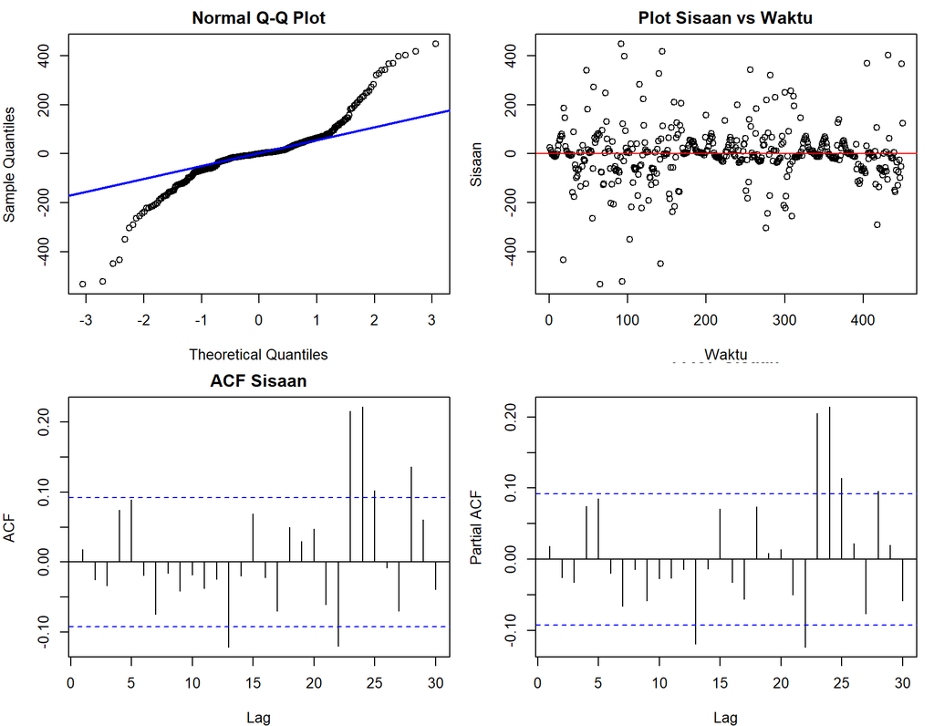

```r
sisaan <- model1$residuals

par(mfrow = c(2,2), mar = c(4,4,2,1))

qqnorm(sisaan, main = "Normal Q-Q Plot")
qqline(sisaan, col = "blue", lwd = 2)

plot(c(1:length(sisaan)), sisaan, type = "p",
     main = "Plot Sisaan vs Waktu", xlab = "Waktu", ylab = "Sisaan")
abline(h = 0, col = "red")

acf(sisaan, lag.max = 30, main = "ACF Sisaan")
pacf(sisaan, lag.max = 30, main = "PACF Sisaan")
```

```r
par(mfrow = c(1,1))
```

Plot kuantil-kuantil normal memperlihatkan titik-titik menyimpang dari garis pada kedua ujung, sehingga sisaan cenderung tidak menyebar normal. Plot sisaan vs waktu memperlihatkan lebar pita yang tidak seragam, yang mengindikasikan ragam tidak homogen. Plot ACF dan PACF sisaan tidak signifikan pada lag-lag awal, tetapi masih terdapat yang signifikan pada lag 22 sampai 25 (serta lag 13 dan 28), lonjakan terbesar ada di lag 23 dan 24 yang merupakan pola harian.

## Uji formal

### Sisaan menyebar normal

```r
ks.test(sisaan, "pnorm", mean = mean(sisaan), sd = sd(sisaan))
```

```
##
##  Asymptotic one-sample Kolmogorov-Smirnov test
##
## data:  sisaan
## D = 0.13918, p-value = 5.366e-08
## alternative hypothesis: two-sided
```

$H_0$ : Sisaan menyebar normal

$H_1$ : Sisaan tidak menyebar normal

Berdasarkan uji tersebut, *p-value* < 5% sehingga tolak $H_0$, artinya **sisaan tidak menyebar normal**. Hal ini sesuai dengan plot kuantil-kuantil normal.

### Sisaan saling bebas

```r
Box.test(sisaan, type = "Ljung")
```

```
##
##  Box-Ljung test
##
## data:  sisaan
## X-squared = 0.1464, df = 1, p-value = 0.702
```

$H_0$ : Sisaan saling bebas

$H_1$ : Sisaan tidak saling bebas

*P-value* uji Ljung-Box lebih besar dari 5% sehingga tak tolak $H_0$, artinya **sisaan saling bebas** pada lag pertama. Sebagai pelengkap, uji pada lag 24:

```r
Box.test(sisaan, lag = 24, type = "Ljung", fitdf = 1)
```

```
##
##  Box-Ljung test
##
## data:  sisaan
## X-squared = 80.418, df = 23, p-value = 2.716e-08
```

Pada lag 24, *p-value* < 5% sehingga masih terdapat autokorelasi sisaan pada lag yang lebih jauh. Autokorelasi ini berasal dari pola harian (periode 24 jam) yang tidak dapat ditangkap oleh model ARIMA non-musiman.

### Ragam sisaan homogen

```r
Box.test((sisaan)^2, type = "Ljung")
```

```
##
##  Box-Ljung test
##
## data:  (sisaan)^2
## X-squared = 7.7639, df = 1, p-value = 0.00533
```

$H_0$ : Ragam sisaan homogen

$H_1$ : Ragam sisaan tidak homogen

*P-value* uji Ljung-Box terhadap sisaan kuadrat < 5% sehingga tolak $H_0$, artinya **ragam sisaan tidak homogen**. Hal ini sesuai dengan plot sisaan vs waktu.

### Nilai tengah sisaan sama dengan nol

```r
t.test(sisaan, mu = 0, conf.level = 0.95)
```

```
##
##  One Sample t-test
##
## data:  sisaan
## t = -0.018967, df = 449, p-value = 0.9849
## alternative hypothesis: true mean is not equal to 0
## 95 percent confidence interval:
##  -10.40983  10.21082
## sample estimates:
##   mean of x
## -0.09950731
```

$H_0$ : Nilai tengah sisaan sama dengan 0

$H_1$ : Nilai tengah sisaan tidak sama dengan 0

*P-value* uji-t > 5% sehingga tak tolak $H_0$, artinya **nilai tengah sisaan sama dengan nol**.

# Tahap 7: Overfitting

*Overfitting* dilakukan dengan menaikkan orde AR dan MA dari model ARIMA(1,0,0), sehingga kandidat model *overfitting* adalah **ARIMA(2,0,0)** dan **ARIMA(1,0,1)**.

## ARIMA(2,0,0)

```r
model1a <- Arima(train.bc, order = c(2,0,0), method = "ML")
summary(model1a)
```

```
## Series: train.bc
## ARIMA(2,0,0) with non-zero mean
##
## Coefficients:
##          ar1      ar2      mean
##       0.7959  -0.0209  396.5208
## s.e.  0.0471   0.0471   23.1182
##
## sigma^2 = 12436:  log likelihood = -2758.86
## AIC=5525.71   AICc=5525.8   BIC=5542.15
##
## Training set error measures:
##                       ME     RMSE      MAE       MPE     MAPE    MASE
## Training set -0.09717767 111.1424 67.70365 -19.98481 33.33679 1.00786
##                     ACF1
## Training set 0.002203289
```

```r
lmtest::coeftest(model1a)
```

```
##
## z test of coefficients:
##
##             Estimate Std. Error z value Pr(>|z|)
## ar1         0.795924   0.047099 16.8990   <2e-16 ***
## ar2        -0.020919   0.047128 -0.4439   0.6571
## intercept 396.520755  23.118151 17.1519   <2e-16 ***
## ---
## Signif. codes:  0 '***' 0.001 '**' 0.01 '*' 0.05 '.' 0.1 ' ' 1
```

## ARIMA(1,0,1)

```r
model1b <- Arima(train.bc, order = c(1,0,1), method = "ML")
summary(model1b)
```

```
## Series: train.bc
## ARIMA(1,0,1) with non-zero mean
##
## Coefficients:
##          ar1     ma1      mean
##       0.7685  0.0284  396.5243
## s.e.  0.0389  0.0619   23.1032
##
## sigma^2 = 12435:  log likelihood = -2758.85
## AIC=5525.7   AICc=5525.79   BIC=5542.14
##
## Training set error measures:
##                       ME     RMSE      MAE      MPE     MAPE     MASE
## Training set -0.09902015 111.1409 67.69945 -19.9888 33.34169 1.007798
##                    ACF1
## Training set 0.00127563
```

```r
lmtest::coeftest(model1b)
```

```
##
## z test of coefficients:
##
##             Estimate Std. Error z value Pr(>|z|)
## ar1         0.768471   0.038945 19.7324   <2e-16 ***
## ma1         0.028376   0.061924  0.4582   0.6468
## intercept 396.524257  23.103206 17.1632   <2e-16 ***
## ---
## Signif. codes:  0 '***' 0.001 '**' 0.01 '*' 0.05 '.' 0.1 ' ' 1
```

```r
overfitting <- data.frame(
  Model = c("ARIMA(1,0,0)", "ARIMA(2,0,0)", "ARIMA(1,0,1)"),
  AIC   = c(AIC(model1), AIC(model1a), AIC(model1b)),
  BIC   = c(BIC(model1), BIC(model1a), BIC(model1b)),
  Parameter_Tidak_Signifikan = c(jml_tidak_sig(model1), jml_tidak_sig(model1a),
                                 jml_tidak_sig(model1b))
)
overfitting
```

```
##          Model      AIC      BIC Parameter_Tidak_Signifikan
## 1 ARIMA(1,0,0) 5523.910 5536.237                          0
## 2 ARIMA(2,0,0) 5525.713 5542.150                          1
## 3 ARIMA(1,0,1) 5525.701 5542.138                          1
```

Kedua model hasil *overfitting* memiliki AIC yang lebih besar dibandingkan ARIMA(1,0,0), dan parameter tambahannya (`ar2` pada ARIMA(2,0,0) dan `ma1` pada ARIMA(1,0,1)) tidak signifikan. Oleh karena itu, model **ARIMA(1,0,0)** tetap digunakan untuk peramalan.

# Tahap 8: Peramalan

Peramalan dilakukan untuk 50 periode ke depan sesuai panjang data uji. Karena model dibangun pada data hasil transformasi $Z_t = Y_t^2$, hasil ramalan dikembalikan ke skala asli dengan transformasi balik $\hat Y_t = \sqrt{\hat Z_t}$.

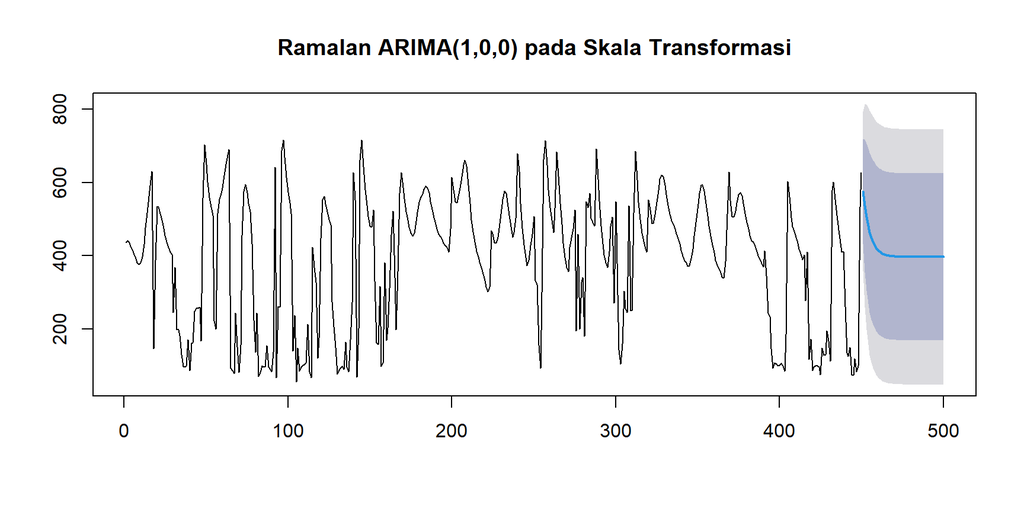

```r
ramalan <- forecast::forecast(model1, h = length(test.ts))
plot(ramalan, main = "Ramalan ARIMA(1,0,0) pada Skala Transformasi")
```

```r
# Transformasi balik ke skala asli
balik <- function(z) sqrt(pmax(z, 0))

hasil <- balik(as.numeric(ramalan$mean))
lo95  <- balik(as.numeric(ramalan$lower[, "95%"]))
hi95  <- balik(as.numeric(ramalan$upper[, "95%"]))

perbandingan <- data.frame(
  Periode  = 451:500,
  Datetime = data500$Datetime[451:500],
  Aktual   = as.numeric(test.ts),
  Forecast = round(hasil, 3),
  Lo95     = round(lo95, 3),
  Hi95     = round(hi95, 3)
)
head(perbandingan, 10)
```

```
##    Periode         Datetime Aktual Forecast   Lo95   Hi95
## 1      451 22/01/2022 18:00 24.433   23.999 18.910 28.184
## 2      452 22/01/2022 19:00 23.933   23.161 16.110 28.519
## 3      453 22/01/2022 20:00 23.150   22.486 14.091 28.507
## 4      454 22/01/2022 21:00 22.600   21.945 12.553 28.383
## 5      455 22/01/2022 22:00 22.167   21.514 11.356 28.227
## 6      456 22/01/2022 23:00 22.033   21.172 10.415 28.072
## 7      457 23/01/2022 00:00 22.067   20.901  9.673 27.931
## 8      458 23/01/2022 01:00 21.967   20.688  9.087 27.810
## 9      459 23/01/2022 02:00 21.650   20.520  8.624 27.709
## 10     460 23/01/2022 03:00 21.333   20.388  8.259 27.625
```

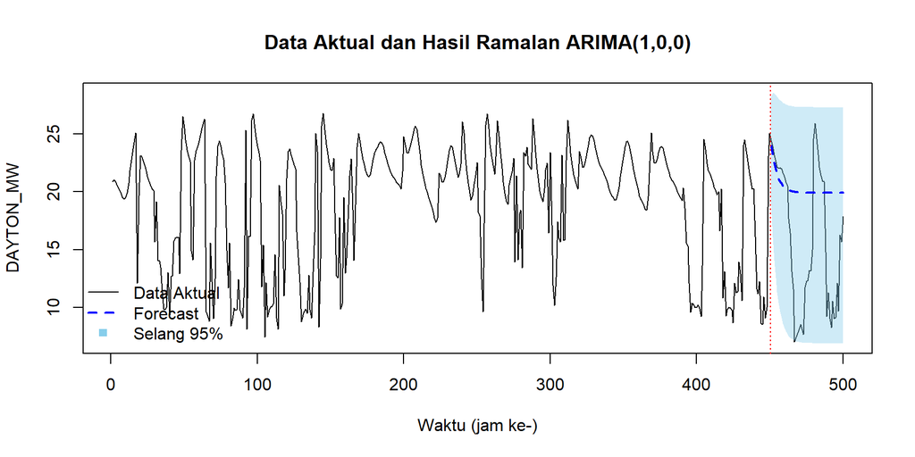

```r
plot(1:500, as.numeric(data.ts), type = "l", col = "black",
     xlab = "Waktu (jam ke-)", ylab = "DAYTON_MW",
     main = "Data Aktual dan Hasil Ramalan ARIMA(1,0,0)",
     ylim = range(c(data.ts, lo95, hi95)))
polygon(c(451:500, 500:451), c(lo95, rev(hi95)),
        col = adjustcolor("skyblue", 0.4), border = NA)
lines(451:500, hasil, col = "blue", lwd = 2, lty = 2)
abline(v = 450.5, col = "red", lty = 3)
legend("bottomleft",
       legend = c("Data Aktual", "Forecast", "Selang 95%"),
       col = c("black", "blue", "skyblue"),
       lty = c(1, 2, NA), lwd = c(1, 2, NA), pch = c(NA, NA, 15), bty = "n")
```

## Akurasi peramalan

```r
akurasi <- accuracy(hasil, as.numeric(test.ts))
akurasi
```

```
##                ME     RMSE      MAE       MPE     MAPE
## Test set -4.40113 7.157108 5.749937 -49.51189 55.28081
```

Model ARIMA(1,0,0) menghasilkan MAPE sebesar 55.28% dan RMSE sebesar 7.157 pada data uji. Ramalan bergerak dari nilai terakhir data latih menuju nilai tengah jangka panjang model, sebagaimana karakteristik model AR(1) yang stasioner. Akibatnya, ramalan tidak mampu mengikuti fluktuasi harian maupun penurunan tajam pada data uji, meskipun hampir seluruh data aktual (98%) masih berada dalam selang kepercayaan 95%. Selang tersebut sangat lebar, sehingga nilai praktisnya terbatas.

# Kesimpulan

1. Data latih (450 amatan) stasioner dalam rataan berdasarkan plot ACF dan uji ADF, tetapi tidak stasioner dalam ragam karena selang kepercayaan $\lambda$ Box-Cox tidak memuat 1. Transformasi kuadrat ($\lambda = 2$) membuat data stasioner dalam ragam.
2. Model tentatif dari ACF, PACF, dan EACF adalah ARIMA(1,0,0), ARIMA(0,0,6), ARIMA(1,0,1), ARIMA(2,0,1), dan ARIMA(3,0,2). ARIMA(3,0,2) memiliki AIC terkecil tetapi tidak invertible, sehingga model terbaik adalah **ARIMA(1,0,0)** dengan AIC terkecil di antara model yang valid dan seluruh parameter signifikan. *Overfitting* ke ARIMA(2,0,0) dan ARIMA(1,0,1) tidak menghasilkan model yang lebih baik.
3. Sisaan model memenuhi asumsi kebebasan pada lag pertama dan nilai tengah nol, tetapi tidak memenuhi asumsi normalitas dan kehomogenan ragam, serta masih mengandung autokorelasi pada lag sekitar 24.
4. Ramalan 50 jam ke depan menghasilkan MAPE 55,28%, sehingga model ARIMA kurang cocok untuk data ini. Penyebab utamanya, data memiliki pola harian (berulang setiap 24 jam) yang tidak dapat ditangkap oleh ARIMA(1,0,0), dan ragam sisaannya tidak homogen. Model yang lebih sesuai adalah SARIMA dengan periode 24 dan GARCH.